# Visualizing Numerical Relationships

Briana Barajas

2024-01-29

## Background and Preparation

Preparation

```r
##~~~~~~~~~~~~~~~~~~~~~~~~~~~~~~~~~~~~~~~~~~~~~~~~~~~~~~~~~~~~~~~~~~~~~~~~~~~~~~
##                                    setup                                 ----
##~~~~~~~~~~~~~~~~~~~~~~~~~~~~~~~~~~~~~~~~~~~~~~~~~~~~~~~~~~~~~~~~~~~~~~~~~~~~~~

#..........................load packages.........................
library(metajam)
library(tidyverse)

knitr::opts_chunk$set(warning = FALSE, message = FALSE)

#...................download data from DataOne...................
# download_d1_data("https://cn.dataone.org/cn/v2/resolve/https%3A%2F%2Fpasta.lternet.edu%2Fpackage%2Fdata%2Feml%2Fknb-lter-hbr%2F208%2F9%2F3b3cf7ea447cb875d7c7d68ebdfd24c7",
#                  path = here::here("week4"))

#  ~ NOTE: I recommend renaming the downloaded folder to 'data/' so that it's ignored by .gitignore! ~

#....................read in downloaded files....................
stream_chem_all <- read_d1_files(here::here("week4", "data"))

#........................get the data file.......................
stream_chem_data <- stream_chem_all$data
```

## Scatter Plots

### Basic

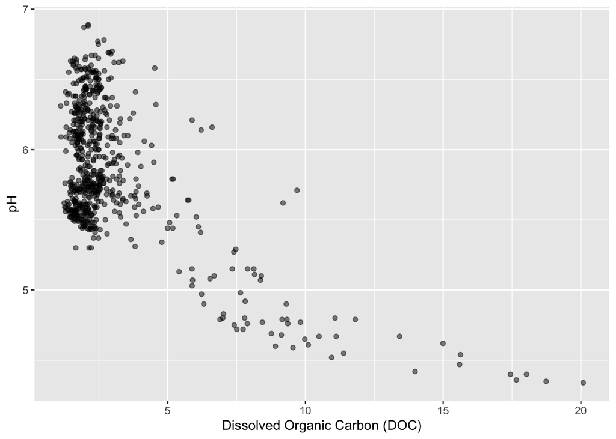

```r
stream_chem_data %>%
  filter(waterYr == 2021) %>%
  ggplot(aes(x = DOC, y = pH)) +
  geom_point(alpha = 0.5) +
  labs(x = "Dissolved Organic Carbon (DOC)")
```

### Marginal Rug Plot

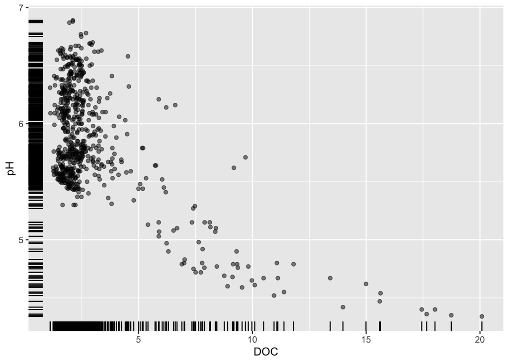

```r
stream_chem_data %>%
  filter(waterYr == 2021) %>%
  ggplot(aes(x = DOC, y = pH)) +
  geom_point(alpha = 0.5) +
  geom_rug()
```

### Marginal Plots with `ggExtra`

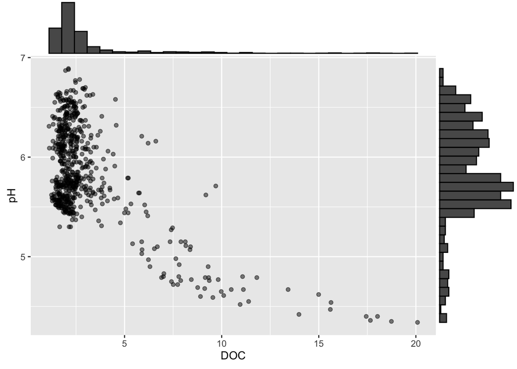

```r
p1 <- stream_chem_data |>
  filter(waterYr == 2021) |>
  ggplot(aes(x = DOC, y = pH)) +
  geom_point(alpha = 0.5)

ggExtra::ggMarginal(p1, type = "histogram")
```

`ggMarginal` offers more options, including boxplots and density plots.

#### Marginal Plots with Groups

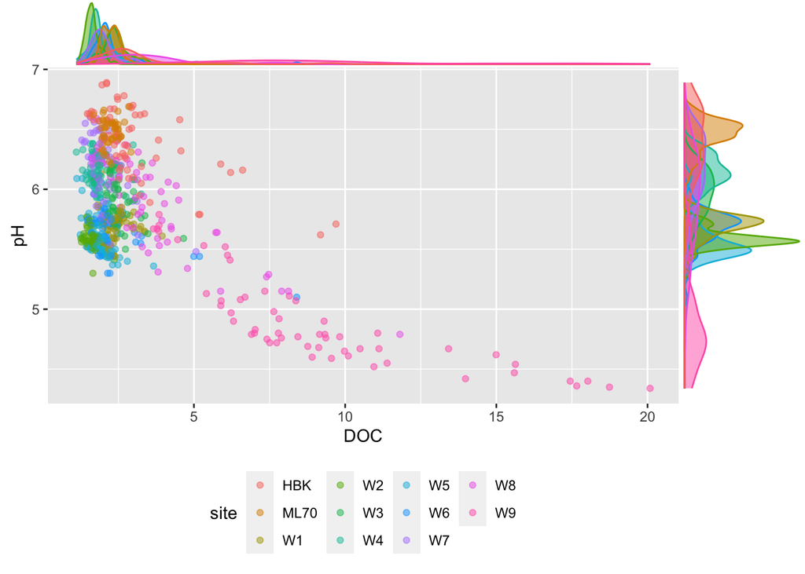

```r
p2 <- stream_chem_data |>
  filter(waterYr == 2021) |>
  ggplot(aes(x = DOC, y = pH, color = site)) +
  geom_point(alpha = 0.5) +
  theme(legend.position = "bottom")

ggExtra::ggMarginal(p2, type = "density",
                    groupFill = TRUE,
                    groupColour = TRUE) #need to spell it Colour
```

## Adding Trendlines

Trendlines can be added using `geom_smooth`

### LOESS Default

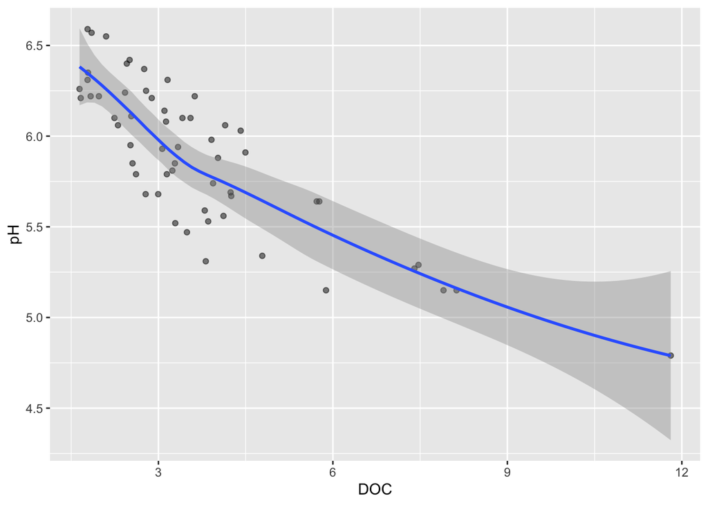

```r
stream_chem_data %>%
  filter(waterYr == 2021) %>%
  filter(site == "W8") |>
  ggplot(aes(x = DOC, y = pH)) +
  geom_point(alpha = 0.5) +
  geom_smooth()
```

`geom_smooth()` defaults to using a method called “LOESS” (locally estimated scatter plot smoothing), which draws a line that’s similar to a moving average. It will also include a confidence interval ribbon

### Line of Best Fit

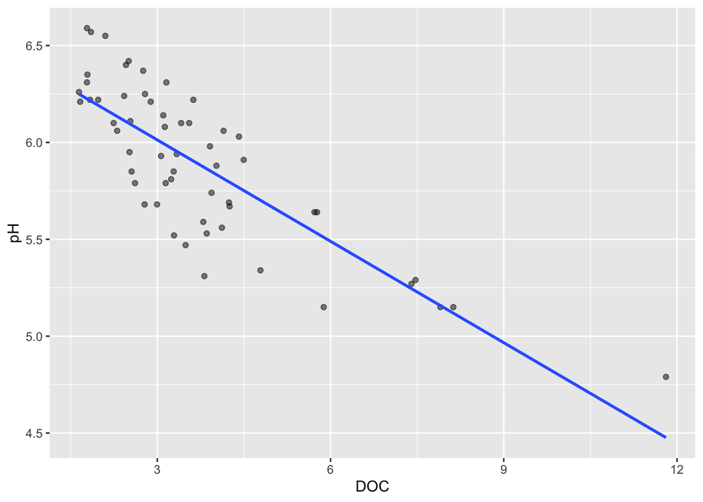

```r
stream_chem_data |>
  filter(waterYr == 2021) |>
  filter(site == "W8") |>
  ggplot(aes(x = DOC, y = pH)) +
  geom_point(alpha = 0.5) +
  geom_smooth(method = "lm", se = FALSE)
```

Best to remove standard error intervals around the line, otherwise it appears to be a truly fit linear model.

## Bubble Charts

Looking at bubble size based on aluminum levels (`AlICP`)

### Default

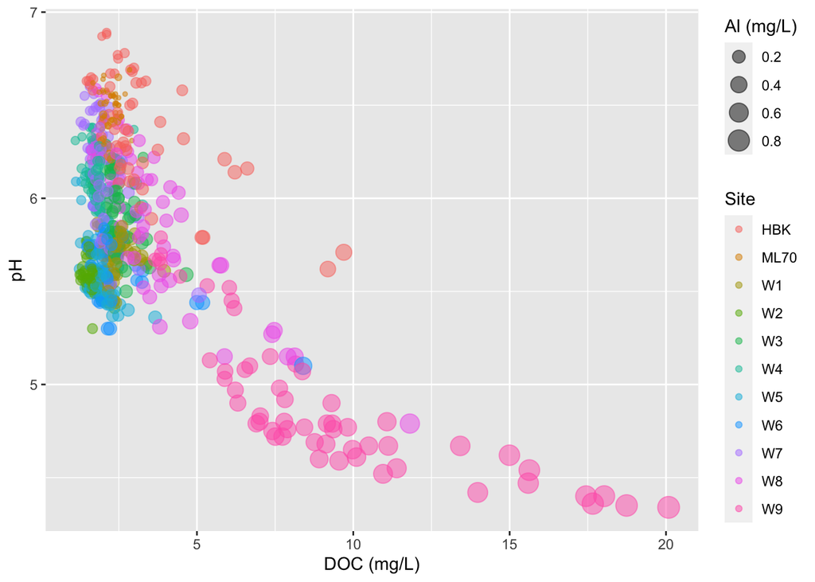

```r
stream_chem_data %>%
  filter(waterYr == 2021) %>%
  ggplot(aes(x = DOC, y = pH, color = site, size = Al_ICP)) +
  geom_point(alpha = 0.5) +
  labs(x = "DOC (mg/L)", size = "Al (mg/L)", color = "Site")
```

### Adjust Size Scale

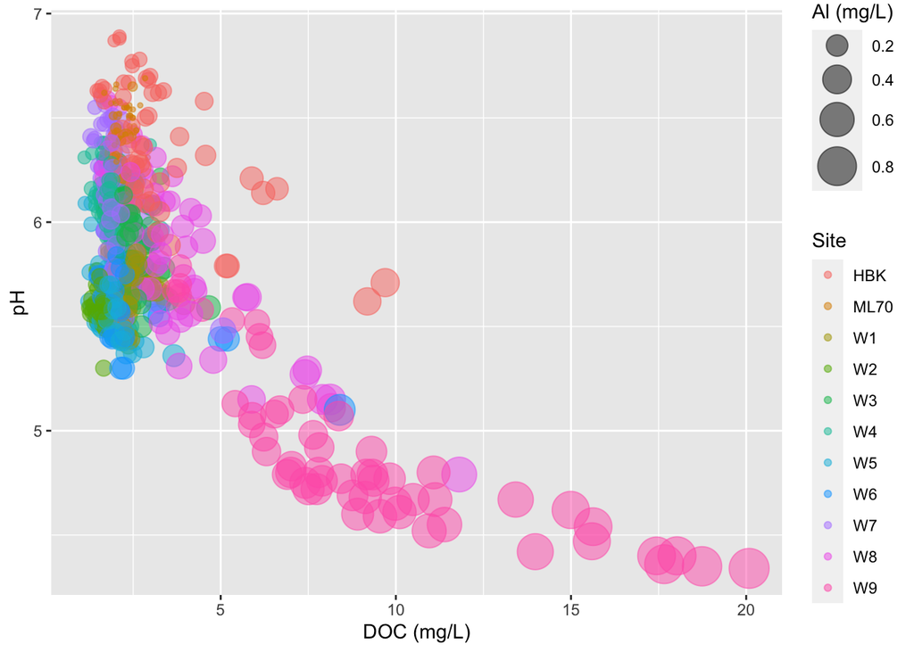

```r
stream_chem_data |>
  filter(waterYr == 2021) |>
  ggplot(aes(x = DOC, y = pH, color = site, size = Al_ICP)) +
  geom_point(alpha = 0.5) +
  scale_size(range = c(1, 10)) +
  labs(x = "DOC (mg/L)", size = "Al (mg/L)", color = "Site")
```

Additional considerations:

- hard to see size difference among groups
- especially if the differences in numeric value is very small
- even with a numeric legend, it’s hard to interpret
- we have an easier time perceiving differences in position rather than size
- the **relationship between your x- and y-axis variables will be the primary focus**
- customizing the bubble size scale can help some of these issues
- **NOTE:** Always scale by area, and NOT radius. Scaling by radius can be much more decieving/harder to interpret
- default settings can work well, but overall important to be cautious
- Note

## Overplotting

The examples above use data from a single year. If all years were to be plotting, the point distribution is too dense to interpret

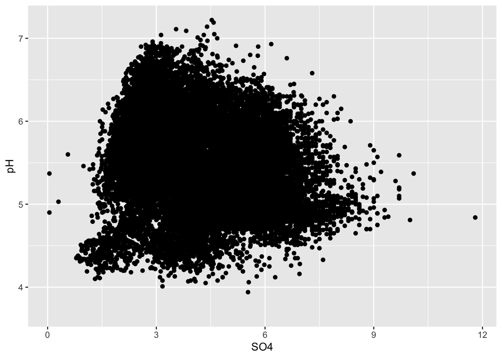

```r
ggplot(stream_chem_data, aes(x = SO4, y = pH)) +
  geom_point()
```

Better plot options for this are 2D-density plots, or heat maps

### Heat map

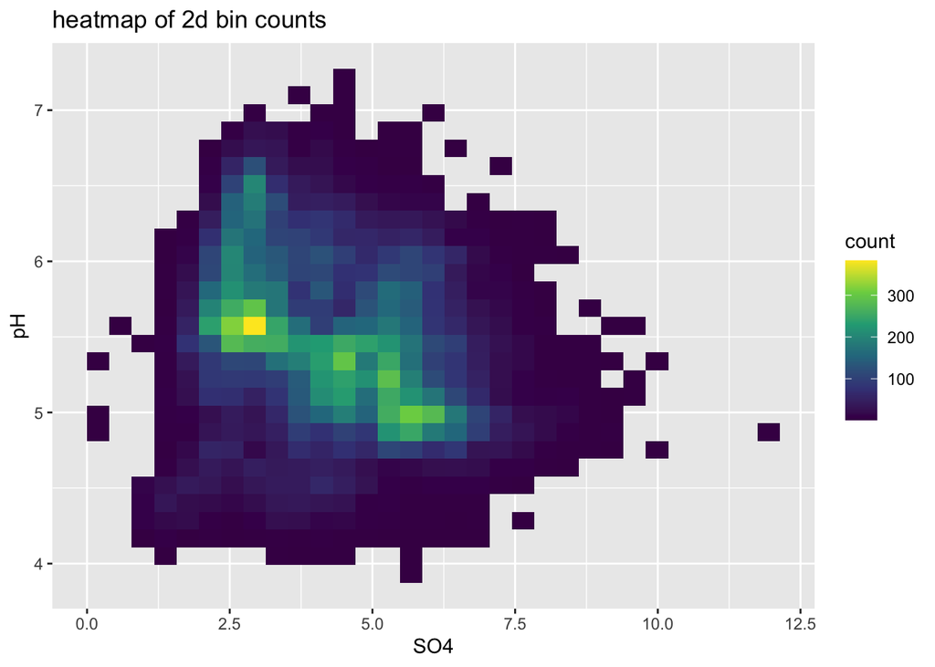

```r
# standard heat map (pixelated)
ggplot(stream_chem_data, aes(x = SO4, y = pH)) +
  geom_bin2d() + #heat map
  scale_fill_viridis_c() +
  labs(title = "heatmap of 2d bin counts")
```

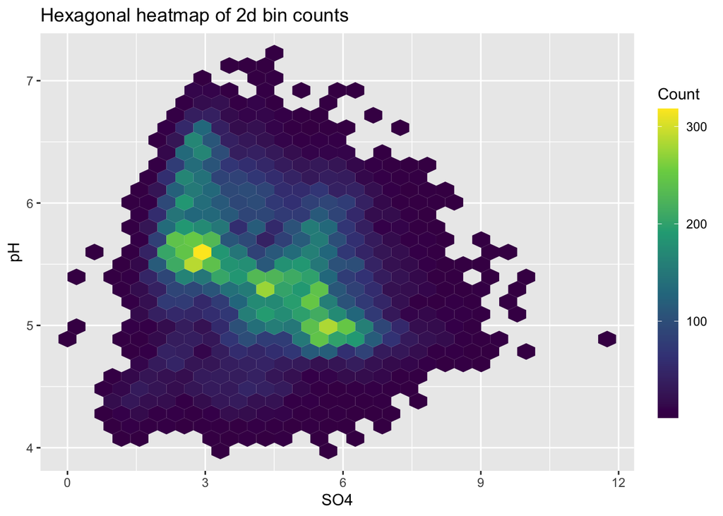

```r
# hexagonal heat map
ggplot(stream_chem_data, aes(x = SO4, y = pH)) +
  geom_hex() + #hexagon map1=
  scale_fill_viridis_c() +
  labs(title = "Hexagonal heatmap of 2d bin counts") +

  # adjust legend appearance for interpretation clarity
  guides(fill = guide_colourbar(title = "Count",
                                barwidth = 1,
                                barheight = 15))
```

### 2D-Density Plot

[Start next lecture (W5)]